# Replication: Is Health Spending Excessive?

Beau Meche

2/7/2020

#### Paper Title: “Is Health Spending Excessive? If So, What Can We Do About It?”

###### Authors: Henry J. Aaron and Paul B. Ginsburg

This paper focuses on using data to sustain the argument that too much is spent on healthcare in the United States - and further that the excess spending is not necessarily superior patient case outcomes. The data used in the paper is primarily OECD data, though it also includes data from the Kaiser Family Foundation and the U.S. Census bureau. I did some research into acquiring said data, but several links in the original research citations are broken at present or allocated to a different server resulting in the same result - lack of acquisition at the present time. I think this topic is particularly interesting as an intersection of my Econ research tutorial and the Gov department is becuase the latter portion of this paper explores ways in which cost could be reduced either structurally or otherwise (policy change) to rectify the claim made by the opening arguments/findings.

Here is a [link to the paper](https://www.healthaffairs.org/doi/pdf/10.1377/hlthaff.28.5.1260) for reference purposes.

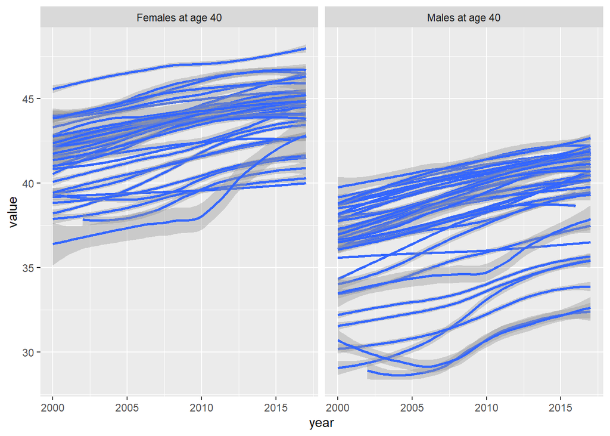

```r
# load in data and triage if needed

life_exp_OECD <- read.csv("data/life_exp_OECD.stat.csv") %>%
  clean_names()

test1 <- life_exp_OECD %>%
  filter(str_detect(variable, pattern = "40") & measure == "Years") %>%
  group_by(variable, country)

test1 %>%
  ggplot(aes(x = year, y = value)) +
  geom_smooth(aes(group = country)) +
  facet_wrap(~variable)
```